# Flight Cancellation Analysis

### Dataset Overview

#### These are six dataset downloaded from ASA website (http://stat-computing.org/dataexpo/2009/the-data.html). They contain flight cancellation information from 2003 to 2008. I will use these dataset to analyze the reasons for cancellation and which airport caused the most of the cancellation.

### Approach: I decide to explore the data in 2008 first. Then I will cross analyze the data from 2003 to 2008.

#### Observation 1: 137434 out of 7009728 flights were cancelled, 2% of the total flights in 2008.

### Question 1: What are the top 10 airports cancelled most of the flights?

```python
# find out the top 10 orign cities having the most of cancelations
df_canceled_origin = df_canceled[['Origin', 'Cancelled']].groupby(['Origin']).count().sort_values('Cancelled', ascending= False)
df_canceled_origin.head(10)
```

| Origin | Cancelled |
| --- | --- |
| ORD | 15050 |
| DFW | 7272 |
| ATL | 5830 |
| LGA | 5753 |
| EWR | 4511 |
| BOS | 3655 |
| IAH | 3261 |
| JFK | 3196 |
| LAX | 2838 |
| SFO | 2790 |

#### Observation 2: 11% of flight cancelation occurred at Chicago O'Hare airport. 5% happened at Dallas DFW airport. 40% of the cancelation happened at the 10 airports above.

### Question 2: What are the reasons for cancellation?

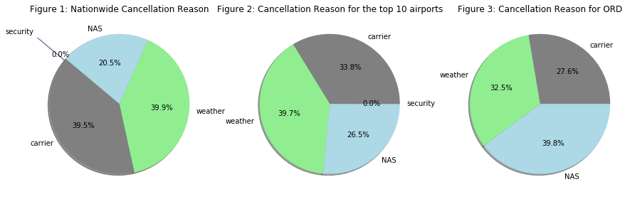

```python
# Next, let's find out the reason of cancelation
labels = ['carrier', 'weather', 'NAS', 'security']
colors  = ["grey", "lightgreen", "lightblue", "blue"]
plt.figure(figsize = [15,10])
# Overall
df_cancel_reason = df_canceled[['Cancelled', 'CancellationCode']].groupby(['CancellationCode']).count()
df_cancel_reason
plt.subplot(1,3,1)
explode = (0, 0, 0, 0.5)  # explode the 4th slide - security
plt.pie(df_cancel_reason, explode=explode, labels=labels, colors = colors, autopct='%1.1f%%', shadow=True, startangle=140);
plt.title('Figure 1: Nationwide Cancellation Reason')

# top 10
top_10 = ['ORD', 'DFW', 'ATL', 'LGA', 'EWR', 'BOS', 'IAH', 'JFK', 'LAX', 'SFO']
df_cancel_reason_10 = df_canceled[df_canceled['Origin'].isin(top_10)][['Cancelled', 'CancellationCode']].groupby(['CancellationCode']).count()
plt.subplot(1,3,2)
plt.pie(df_cancel_reason_10, labels=labels, colors = colors, autopct='%1.1f%%', shadow=True);
plt.title('Figure 2: Cancellation Reason for the top 10 airports')


# ORD
df_cancel_reason_ord = df_canceled[df_canceled['Origin']=='ORD'][['Cancelled', 'CancellationCode']].groupby(['CancellationCode']).count()
plt.subplot(1,3,3)
labels = ['carrier', 'weather', 'NAS']
colors  = ["grey", "lightgreen", "lightblue"]
plt.pie(df_cancel_reason_ord, labels=labels, colors = colors, autopct='%1.1f%%', shadow=True)
plt.title('Figure 3: Cancellation Reason for ORD');
```

### Let's find the cancelled flights for each airline in each month.

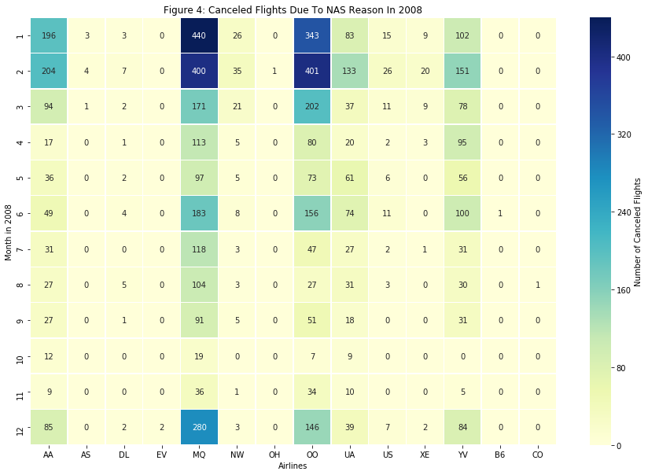

```python
# plot the heatmap
plt.figure(figsize = [15,10])
ax = sb.heatmap(df_heatmap, annot = True, fmt = 'd', linewidths=.5, cmap="YlGnBu",cbar_kws={'label': 'Number of Canceled Flights'});
plt.xlabel("Airlines");
plt.ylabel("Month in 2008");
plt.title("Figure 4: Canceled Flights Due To NAS Reason In 2008");
```

#### Observation 4: In total, the issue of NAS cancelled 5,991 flights. The result shows MQ (Envoy Air Inc., formerly American Eagle Airlines) and OO (SkyWest) owned 3,619 flights, 60% of the total cancelled flights.

#### Observation 5: 2,602 flights, 43% of the cancellation, were cancelled in January and February due to NAS. This is surprising since I expected December would have the most cancellations because of the heavy holiday traffic. Only 650 flights were cancelled in December.

### Question 3: Why did Envoy and SkyWest cancel so many flights? What could be the reasons? Would it be possible they cancelled because they had a lot of flights to depart from O’Hare? What were other airlines departing from O’Hare? Did they depart more or less than Envoy Air and SkyWest?

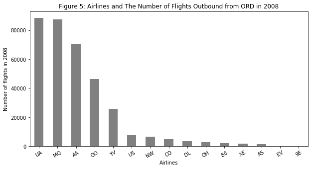

```python
# count of total flights in 2008 from ORD
df_2008_ord = df_2008[df_2008['Origin'] == "ORD"]

# plot a histogram
plt.figure(figsize=[10,5])
df_2008_ord['UniqueCarrier'].value_counts().plot(kind='bar', color = 'grey')
plt.xlabel("Airlines")
plt.xticks(rotation=30)
plt.ylabel("Number of flights in 2008")
plt.title("Figure 5: Airlines and The Number of Flights Outbound from ORD in 2008");
```

```python
df_2008_ord_count = df_2008_ord.groupby('UniqueCarrier').size().reset_index(name='Count')
df_2008_ord_count.sort_values('Count', inplace = True, ascending=False)
df_2008_ord_count.head(12)
```

|  | UniqueCarrier | Count |
| --- | --- | --- |
| 11 | UA | 88687 |
| 7 | MQ | 87437 |
| 1 | AA | 70550 |
| 10 | OO | 46316 |
| 14 | YV | 25897 |
| 12 | US | 7607 |
| 8 | NW | 6774 |
| 4 | CO | 4992 |
| 5 | DL | 3539 |
| 9 | OH | 2986 |
| 3 | B6 | 2356 |
| 13 | XE | 1736 |

#### Observation 6: United Airlines (UA) had the most flights from O’Hare in 2008. Envoy, American Airlines (AA) and SkyWest ranked #2, #3 and #4. United and Envoy were tie.

### Question 4: Why did Envoy cancel more flights than United? Maybe the departure time can provide further information. Was there a timeframe in which more flights were canceled? I am going to look at the scheduled departure time.

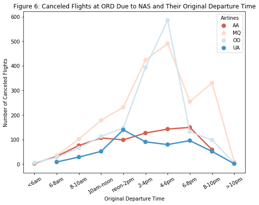

```python
# plot a line plot
plt.figure(figsize = [8,6])
ax = sb.pointplot(data = df_canceled_ord_nas_deptime, x = 'Timeframe', y = 'Count', hue = 'UniqueCarrier', palette = sb.color_palette("RdBu", 4))

plt.xticks(rotation=30)
plt.title("Figure 6: Canceled Flights at ORD Due to NAS and Their Original Departure Time");
plt.xlabel("Original Departure Time")
plt.ylabel("Number of Canceled Flights")
plt.legend(title = 'Airlines')
plt.show();
```

#### Observation 7: From noon to 6pm, the number of cancelled flights increased for Envoy, SkyWest and American. Possible evidence for this is because there are more flights in the afternoon. The cancellation increased dramatically for Envoy and SkyWest. However, United cancelled less flights in the afternoon. I assume there was an NAS resource competition between United and Envoy/SkyWest. Why?

### Question 5: What about other cancellation reasons? Are there any clues suggesting a correlation?

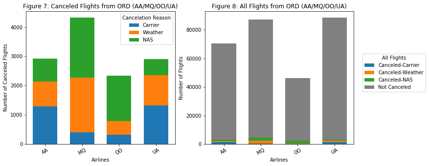

```python
# plot two bar charts
plt.figure(figsize = [12, 5])
width = 1/1.5

# left plot: bar chart with only cancled flights and the cancelation reasons from the top 4 airlines
plt.subplot(1, 2, 1)
plt.bar([1,2,3,4], df_ord_cancel_non['A'], width)
plt.bar([1,2,3,4], df_ord_cancel_non['B'], width, bottom=df_ord_cancel_non['A'])
plt.bar([1,2,3,4], df_ord_cancel_non['C'], width, bottom=df_ord_cancel_non['B']+ df_ord_cancel_non['A'])
plt.title("Figure 7: Canceled Flights from ORD (AA/MQ/OO/UA)")
plt.xlabel("Airlines")
plt.xticks([1,2,3,4], ['AA', 'MQ', 'OO', 'UA'])
plt.xticks(rotation = 30)
plt.ylabel("Number of Canceled Flights")
plt.legend(['Carrier', 'Weather', 'NAS'], title='Cancelation Reason');

# right plot: bar chart with all flight, including the ones not canceled, from the top 4 airlines
plt.subplot(1, 2, 2)
plt.bar([1,2,3,4], df_ord_cancel_non['A'], width)
plt.bar([1,2,3,4], df_ord_cancel_non['B'], width, bottom=df_ord_cancel_non['A']);
plt.bar([1,2,3,4], df_ord_cancel_non['C'], width, bottom=df_ord_cancel_non['B']+ df_ord_cancel_non['A'])
plt.bar([1,2,3,4], df_ord_cancel_non['N'], width, bottom=df_ord_cancel_non['B']+ df_ord_cancel_non['A']+df_ord_cancel_non['C'], color = "gray")
plt.title("Figure 8: All Flights from ORD (AA/MQ/OO/UA)")
plt.xlabel("Airlines")
plt.xticks([1,2,3,4], ['AA', 'MQ', 'OO', 'UA'])
plt.xticks(rotation=30)
plt.ylabel("Number of Flights")
plt.legend(['Canceled-Carrier', 'Canceled-Weather', 'Canceled-NAS', 'Not Canceled'], loc=0,bbox_to_anchor=(0,0,1.5,0.7), title='All Flights');
```

#### Observation 8: Figure 8 shows Figure 7 in scale of total flights, in contrast to only cancelled flights in Figure 7. Though United and Envoy had a similar number of flights, Envoy cancelled more flights due to NAS. Similarly, though American had more flights than SkyWest, SkyWest cancelled more flights due to NAS.

### Last, I would like to look at the trend of flight cancellation at O’Hare for American, Envoy, SkyWest and United between 2003 and 2008 to find out the NAS-cancellation situation a few years before.

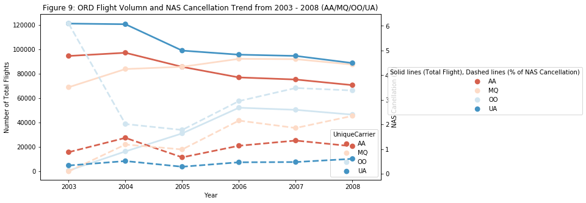

```python
# plot a multivariable line plot, left y-axis is flight volume, right y-axis is percetage of NAS cancellation
fig = plt.figure(figsize = [10,5])
dots = sb.load_dataset("dots").query("align == 'dots'")

ax1 = fig.add_subplot(111) # Create matplotlib axes
ax2 = ax1.twinx()           # Create another axes that shares the same 'YEAR' x-axis as ax1.

# left y-axis: flight number
sb.pointplot(data=df_ord_years, x='Year', y='TotalFlight', hue='UniqueCarrier', ax=ax1, palette=sb.color_palette("RdBu", 4))

# right y-axis: % of NAS cancelation
sb.pointplot(data=df_ord_years, x='Year', y='NAS(%)', hue='UniqueCarrier', linestyles='--', palette=sb.color_palette("RdBu", 4),ax=ax2,legend=False)

# add labels and ticks etc
plt.xticks(rotation=30)
plt.title("Figure 9: ORD Flight Volumn and NAS Cancellation Trend from 2003 - 2008 (AA/MQ/OO/UA)");
plt.xlabel("Year")
ax1.set_ylabel("Number of Total Flights")
ax2.set_ylabel('NAS Canellation (%)')
ax1=plt.legend(loc=0,bbox_to_anchor=(0,0,1.6,0.7), title = "Solid lines (Total Flight), Dashed lines (% of NAS Cancellation)")
plt.show();
```

#### Observation 9: Both United and American decreased the total number of outbound flights from O’Hare airport since 2003. However, Envoy and SkyWest increased the number flights. SkyWest increased the number flights for nearly 117 times.

#### Observation 10: the percentage of NAS-cancellation rate, which did not change much for United and American. The rate increased for Envoy. The rate for SkyWest was the highest in 2003, mainly because there were only around 400 flights in that year. It dropped dramatically in 2004 but has climbed up steadily since 2005.

#### Observation 11: Overall, Envoy and SkyWest had higher NAS-cancellation rate than United and American. The fact that the NAS-cancellation rate of United and American had not had much change indicates O’Hare maintains NAS-scheduling priority for United and American, two of the mainline carriers in the U.S., over smaller carriers.